# Лабораторная работа №4

Адресация IPv4 и IPv6.Двойной стек

Устинова В. В.

Российский университет дружбы народов, Москва, Россия

24 октября 2026

# Информация

## Докладчик

- Устинова Виктория Вадимовна
- студент НПИбд-01-24
- Российский университет дружбы народов

## Цель работы

Изучение принципов распределения и настройки адресного пространства на устройствах сети.

## Задание

Настроить двойной стек адресации IPv4 и IPv6 в локальной сети. В соответствии с таблицей адресации настроить интерфейсы оконечных устройств (PC1, PC2, Server) и маршрутизатора FRR. Проверить связь между устройствами с помощью команд ping и trace. Посмотреть захваченный трафик ARP, ICMP, ICMPv6 на соединении сервера с коммутатором и пояснить извлеченную информацию.

# Выполнение лабораторной работы

## Общий вид топологии в GNS3

Построить топологию сети с двумя локальными подсетями, маршрутизаторами frr and vyos, коммутаторами, оконечными устройствами и сервером

[figure not shown]

В рабочей области GNS3 размещены устройства PC1-PC4, server,коммутаторы msk-vvustinova-sw-01..05, маршрутизаторы msk-vvustinova-gw-01 (frr), msk-vvustinova-gw-02 vyos

## Соединения устройств и захват трафика.

Соединить устройства в соответствии с топологией и включить захват трафика на соединении сервера с коммутатором

[figure not shown]

Показаны порты соединений (e0, e1, eth0, eth1, eth2). К серверу подключен коммутатор sw-05 через порт e7.

## Настройка и проверка IPv4 на PC1.

Задать IP-адресацию для PC1 и просмотреть конфигурацию IPv4 и IPv6.

[figure not shown]

Выполнена команда show ip: IP/MASK 172.16.20.10/25, GATEWAY 172.16.20.1. В show ipv6 показан LINK-LOCAL SCOPE fe80::250:79ff:fe66:6800/64.

## Настройка IPv4 на PC2.

Задать IPv4-адресацию для PC2 и просмотреть конфигурацию.

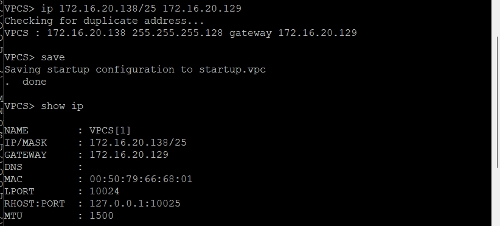

Выполнена команда ip 172.16.20.138/25 172.16.20.129, настройки сохранены. show ip показывает IP/MASK 172.16.20.138/25, GATEWAY 172.16.20.129.

## Настройка IPv4 на сервере.

Задать IPv4-адресацию для сервера.

[figure not shown]

Выполнена команда ip 64.100.1.10/24 64.100.1.1, адрес успешно назначен.

## Настройка интерфейсов маршрутизатора FRR.

Настроить IPv4-адресацию на интерфейсах локальной сети маршрутизатора FRR msk-vvustinova-gw-01 согласно таблице.

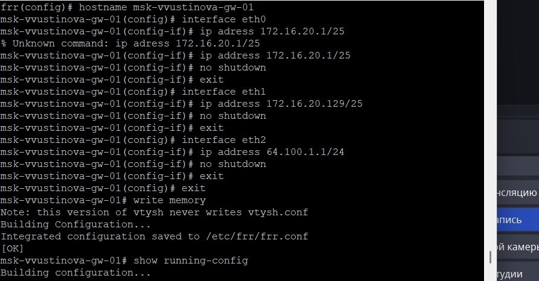

Задан hostname, интерфейсам eth0, eth1, eth2 назначены адреса 172.16.20.1/25, 172.16.20.129/25 и 64.100.1.1/24 соответственно, выполнены команды no shutdown и write memory.

## Проверка конфигурации FRR.

Проверить конфигурацию маршрутизатора и настройки IPv4-адресации.

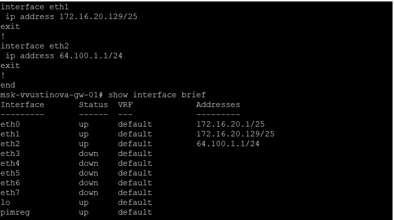

show running-config отображает конфигурацию интерфейсов. show interface brief показывает, что eth0, eth1 и eth2 находятся в состоянии up с назначенными адресами.

## Проверка связи

Проверить подключение с помощью команд ping и trace. Узлы PC1 и PC2 должны отправлять эхо-запросы друг другу и на сервер.

[figure not shown]

Ping до 64.100.1.10 завершается тайм-аутом. Trace до 172.16.20.138 доходит до узла. Trace до 64.100.1.10 прерывается на 172.16.20.1 с ошибкой Destination host unreachable.

Проверить связь между PC2, PC1 и сервером.

[figure not shown]

Ping до 172.16.20.10 успешно проходит (5 пакетов). Ping до 64.100.1.10 завершается тайм-аутом.

Посмотреть захваченный на соединении сервера двойного стека с коммутатором трафик ARP, ICMP, ICMPv6 и пояснить извлеченную информацию.

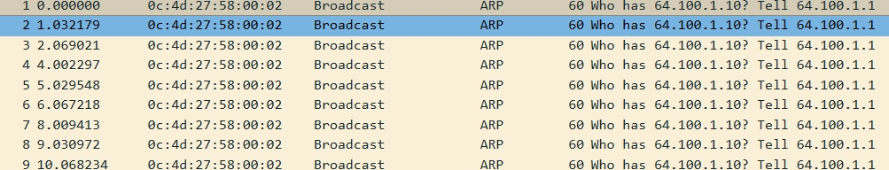

В Wireshark видны широковещательные ARP-запросы от узла с MAC 0c:4d:27:58:00:02: Who has 64.100.1.10? Tell 64.100.1.1.